# AircraftPreliminaryDesignv1.0

```python
import numpy as np
import matplotlib.pyplot as plt
```

UNIT CONVERSIONS:

1 feet = 0.3048 meters

1 pound = 0.453592 kilograms

1 nautical mile = 1852 meters

```python
################# UNIT CONVERSIONS ##################

ft_to_m = 0.3048;
lb_to_kg = 0.453592;
nmi_to_m = 1852;
knot_to_m = 0.51444;
deg_to_rad = np.pi/180;
l_to_mcube = 0.001;
```

```python
################# GIVEN VARIABLES ##################

payload_weight = 92000*lb_to_kg;  #input in pounds
crew_weight = 2300*lb_to_kg; #input in pounds
Range = 3500*nmi_to_m; #input in nautical miles
takeoff_length = 9000*ft_to_m; #input in feet
endurance_time = 0;
g = 9.8;
```

```python
################# SELF-MADE ASSUMPTIONS #################

stall_speed = 63;
wing_loading = np.arange(4500)+3800; #(wing loading maximum of 8300)
rho_0 = 1.225;
```

```python
################# ASSUMPTIONS FROM SIMILAR AIRCRAFT ##################

service_ceiling = 11100;
absolute_ceiling = 12000;
cruise_ceiling = 10700;
stall_speed = 63;
max_velocity = 275;
cruise_velocity = 250;
rate_of_climb_max = 18.5; #assumed using data from Boeing 747-A and 747-B
```

```python
################## ASSUMPTIONS FROM SADRAEY WEIGHT ESTIMATION CHAPTER####################

e = 0.85;
aspect_ratio = 9;
mu = 0.02; #worst case where runway is icy concrete/asphalt
sfc = 14.1 * 0.000001; #high bypass turbofans
a = -7.754 * 0.00000001;
b = 0.576;
taxi_takeoff_weight_fraction = 0.98;
climb_weight_fraction = 0.97;
descent_weight_fraction = 0.99;
land_approach_weight_fraction = 0.997;
CL_max_clean = 1.5; #Roskam Part I
CL_max_To = 2.2; #Roskam Part I
CL_max_L = 2.8; #Roskam Part I
CL_max_approach = 2.4; #Roskam PArt I
CL_takeoffrotation = CL_max_To/(1.1**2);
LbyD_max = 16;
CL_flap = 0.6;
CD_0 = 0.02;
CD_0_landinggear = 0.01; #Roskam
CD_0_highliftdevice = 0.01; #Roskam
velocity_rotation = 1.2 * stall_speed;
v_approach_landing = np.sqrt((takeoff_length/ft_to_m)/0.3)*knot_to_m; ##ROskam
v_stall_landing = v_approach_landing/1.3; ##ROskam
CL_landing_climb = CL_max_L/(1.3**2); ##ROskam
CL_approach_climb = CL_max_approach/(1.5**2); #Roskam
```

**Take-off Weight Estimation**

$W_{\text{TO}} = \frac{W_{\text{PL}} + W_{C}}{1 - \frac{W_{F}}{W_{\text{TO}}} - \frac{W_{E}}{W_{\text{TO}}}}$

$$W_{\text{TO}}\ :Take - off\ weight$$$$W_{\text{PL}}\ :Payload\ weight$$$$W_{C}\ :Crew\ weight$$$$W_{F}\ :Fuel\ weight$$$$W_{E}\ :Empty\ weight$$

**Payload Weight:**

$$W_{\text{PL}} = W_{\text{passengers\ }} + \ W_{\text{baggage}}$$$$W_{\text{PL}} = \left( 400 \times 200 \right) + \left( 400 \times 30 \right) = 92000\ lbs \approx 41000\ kg$$

**Crew Weight:**

$$W_{C} = W_{\text{crew\ }} + \ W_{\text{baggage}}$$$$W_{C} = \left( 10 \times 200 \right) + \left( 10 \times 30 \right) = 2300 lbs \approx 1000\ kg$$

**Fuel ratio:**

*Cruise: (using Breguet Range Equation)*

Assumptions:

$\left( \frac{L}{D} \right)_{\max}$= 16

R = 3500 nmi = 6500 km

$$v_{c} = 0.82\ Mach = 900\frac{\text{km}}{\text{hr}}\text{from similar aircraft}$$

This cruise velocity is Carson’s velocity, not velocity as $\left( \frac{L}{D} \right)_{\max}$.

$$v_{\left( \frac{L}{D} \right)_{\max}} = \frac{v_{c}}{1.32} \approx 680\ km/h$$$$\left( \frac{W_{i + 1}}{W_{i}} \right) = e^{\frac{- R \times C \times g}{0.866 \times v_{c} \times \left( \frac{L}{D} \right)_{\max}}}$$

C: specific fuel consumption = 14.1 mg/N.s for cruise for high-bypass turbofan engines (assumption from historical data)

$$\left( \frac{W_{i + 1}}{W_{i}} \right)_{\text{cruise}} = 0.78$$

*Loiter:*

Considering a loiter time of 30 minutes:

$$\left( \frac{W_{i + 1}}{W_{i}} \right)_{\text{loiter}} = e^{\frac{- E \times C \times g}{\left( \frac{L}{D} \right)_{\max}}} = 0.968$$

C = 17.625 mg/N.s for loiter

*Other conditions: (from historical data)*

$$\left( \frac{W_{i + 1}}{W_{i}} \right)_{\text{taxi and takeoff}} = 0.98$$$$\left( \frac{W_{i + 1}}{W_{i}} \right)_{\text{climb}} = 0.97$$$$\left( \frac{W_{i + 1}}{W_{i}} \right)_{\text{descent}} = 0.99$$$$\left( \frac{W_{i + 1}}{W_{i}} \right)_{\text{approach and landing}} = 0.997$$

*Net weight ratio after landing and before take-off:*

Due to safety considerations, 5% of aircraft weight of fuel must be kept extra.

So,

**Empty Weight:**

Empty Weight fraction from similar aircraft:

Airbus A340: 0.48

Boeing 777-300: 0.525

Airbus A380-841: 0.485

Using this, we have considered empty weight fraction,

$$\left( \frac{W_{E}}{W_{\text{TO}}} \right) = a \times W_{\text{TO}} + b,\ where\ a = \ - 7.754 \times 10^{- 8}\ and\ b = 0.576$$$$We\ get\ this\ value\ to\ be\ 0.5547\ after\ evaluation.$$

*Estimating take-off weight:*

Using the above calculated and observed values, and plugging into the first equation, we get a rough estimate of the take-off weight of the airplane.

```python
################# DERIVED VARIABLES USING ASSUMPTIONS AND GIVEN VARIABLES #################


sigma_cruise = (1-(22.549*0.000001*cruise_ceiling))**4.26;
sigma_service = (1-(22.549*0.000001*service_ceiling))**4.26;
rho_service = sigma_service * rho_0;
k = 1/(np.pi*e*aspect_ratio);
sigma_absolute = (1-(22.549*0.000001*absolute_ceiling))**4.26;
rho_cruise = sigma_cruise * rho_0;
CL_takeoff = CL_max_To/1.44; #Roskam Part I
CL_en_cl = CL_max_clean/(1.25**2); #Roskam Part I
CD_en_cl = CD_0 + (k*((CL_en_cl**2))); #Roskam Part I
CD_0_sec_seg_cl = CD_0 + CD_0_highliftdevice; #Roskam Part I
CD_0_takeoff = CD_0 + CD_0_landinggear + CD_0_highliftdevice;
CD_0_landing = 0.08; #Roskam Part I
CD_0_approach = (CD_0_landing+CD_0_takeoff)/2; #Roskam Part I
CD_sec_seg_cl = CD_0_sec_seg_cl + (k*(CL_takeoff**2)); #Roskam Part I
CD_takeoff = CD_0_takeoff + (k*(CL_takeoff**2));
CD_landing_climb = CD_0_landing + (k*(CL_landing_climb**2)); #Roskam Part I
CD_approach_climb = CD_0_approach + (k*(CL_approach_climb**2)); #Roskam Part I
CD_G = CD_takeoff-(mu*CL_takeoff);
```

Take-off Weight Estimation:

The code below estimates the maximum take-off weight of the aircraft using the weight fractions method illustrated in Sadraey. In the code, empty weight fraction has been assumed to be a function of the total weight.

```python
################ Take-off Weight Estimation Program (SADRAEY METHOD) #################

cruise_weight_fraction = np.exp(-(Range*sfc*g)/(0.866*cruise_velocity*LbyD_max));
loiter_weight_fraction = np.exp(-(endurance_time*sfc*g)/LbyD_max);
land_takeoff_fraction = cruise_weight_fraction*loiter_weight_fraction*taxi_takeoff_weight_fraction*climb_weight_fraction*descent_weight_fraction*land_approach_weight_fraction;
fuel_weight_fraction = 1.05 * (1 - land_takeoff_fraction);
weight = ((-b+1-fuel_weight_fraction)-np.sqrt(((-b+1-fuel_weight_fraction)*(-b+1-fuel_weight_fraction))-(4*a*(payload_weight+crew_weight))))/(2*a);
empty_weight_fraction = (a*weight) + b;
print("Maximum take-off weight =",weight,"kgs\nEmpty weight: ",empty_weight_fraction*weight,"kgs");
```

```
Maximum take-off weight = 274226.93684344244 kgs
Empty weight:  152123.67560629058 kgs
```

The code below calculates the thust loading required for various flight conditiosn to be met. The flight conditions assumed are:

Maximum Speed, Take-off Length, Maximum Rate of Climb, Absolute Ceiling, Service Ceiling, and Cruise Ceiling

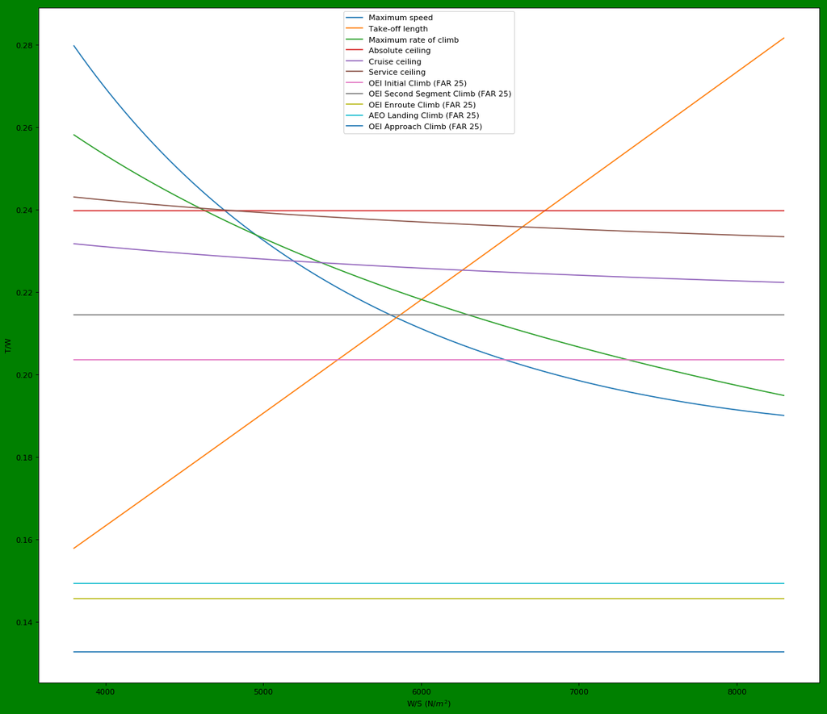

```python
##### Thrust Loading vs. Wing Loading (SADRAEY METHOD) #####

thrust_loading_1 = (0.5*rho_0*(max_velocity**2)*CD_0/wing_loading) + (2*k*wing_loading/(rho_cruise*sigma_cruise*(max_velocity**2)));
thrust_loading_2 = (mu-((mu+(CD_G/CL_takeoffrotation))*np.exp(0.6*rho_0*9.8*CD_G*takeoff_length/wing_loading)))/(1-np.exp(0.6*rho_0*9.8*CD_G*takeoff_length/wing_loading));
thrust_loading_3 = (rate_of_climb_max/np.sqrt(2*wing_loading/(rho_0*np.sqrt(CD_0/k)))) + (1/LbyD_max);
thrust_loading_4 = 1/(sigma_absolute*LbyD_max) + 0*wing_loading;
thrust_loading_5 = (1.524/(sigma_cruise*np.sqrt(2*wing_loading/(rho_cruise*np.sqrt(CD_0/k))))) + (1/(sigma_cruise*LbyD_max));
thrust_loading_6 = (1.524/(sigma_service*np.sqrt(2*wing_loading/(rho_service*np.sqrt(CD_0/k))))) + (1/(sigma_service*LbyD_max));
thrust_loading_7 = 2*((CD_takeoff/CL_takeoff)+0.012) + (0*wing_loading); ##Roskam (FAR 25)
thrust_loading_8 = 2*((CD_sec_seg_cl/CL_takeoff)+0.024) + (0*wing_loading); ##Roskam (FAR 25)
thrust_loading_9 = 2*((CD_en_cl/CL_en_cl)+0.012) + (0*wing_loading); ##Roskam (FAR 25)
thrust_loading_10 = ((CD_landing_climb/CL_landing_climb)+0.032) + (0*wing_loading); ##Roskam (FAR 25)
thrust_loading_11 = ((CD_approach_climb/CL_approach_climb)+0.032) + (0*wing_loading); ##Roskam (FAR 25)
plt.figure(figsize=(18, 16), dpi= 80, facecolor='g', edgecolor='k')
plt.plot(wing_loading,thrust_loading_1);
plt.plot(wing_loading,thrust_loading_2);
plt.plot(wing_loading,thrust_loading_3);
plt.plot(wing_loading,thrust_loading_4);
plt.plot(wing_loading,thrust_loading_5);
plt.plot(wing_loading,thrust_loading_6);
plt.plot(wing_loading,thrust_loading_7);
plt.plot(wing_loading,thrust_loading_8);
plt.plot(wing_loading,thrust_loading_9);
plt.plot(wing_loading,thrust_loading_10);
plt.plot(wing_loading,thrust_loading_11);
plt.xlabel("W/S (N/$m^2$)")
plt.ylabel("T/W")
plt.legend([("Maximum speed"),("Take-off length"),("Maximum rate of climb"),("Absolute ceiling"),("Cruise ceiling"),("Service ceiling"),("OEI Initial Climb (FAR 25)"),("OEI Second Segment Climb (FAR 25)"),("OEI Enroute Climb (FAR 25)"),("AEO Landing Climb (FAR 25)"),("OEI Approach Climb (FAR 25)")]);
```

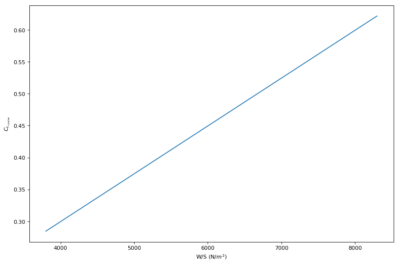

```python
##Determining CL_cruise##

CL_cruise = wing_loading*(1-(0.4*fuel_weight_fraction))/(0.5*rho_cruise*(cruise_velocity**2)); ######Roskam Part II
plt.figure(figsize=(12, 8), dpi= 80, facecolor='w', edgecolor='k')
plt.plot(wing_loading,CL_cruise);
plt.xlabel("W/S (N/$m^2$)");
plt.ylabel("$C_{L_{cruise}}$")
```

[figure not shown]

```python
##Estimating CL_max based on stall speed requirements##

CL_max_calc = wing_loading/(0.5*rho_0*(stall_speed**2));
plt.figure(figsize=(18, 16), dpi= 80, facecolor='w', edgecolor='k')
plt.plot(wing_loading,CL_max_clean+(0*wing_loading));
plt.plot(wing_loading,CL_max_To+(0*wing_loading));
plt.plot(wing_loading,CL_max_calc);
plt.plot(wing_loading,CL_max_L+(0*wing_loading));
plt.plot(wing_loading,CL_max_approach+(0*wing_loading));
plt.xlabel("Wing Loading (N/$m^2$)");
plt.ylabel("$C_{L_{max_{req}}}$");
plt.legend({("Calculated $C_{L_{max_{req}}}$"),("Assumed $C_{L_{max_{clean}}}$"),("Assumed $C_{L_{max_{takeoff}}}$"),("Assumed $C_{L_{max_{landing}}}$"),("Assumed $C_{L_{max_{approach}}}$")});
```

**Major Airline Manufacturers:**

- Airbus (France/Germany/Spain/United Kingdom): Useful
- Boeing (United States): Useful
- Antonov (Ukraine): Military strategic cargo, transport
- ATR Aircraft (France/Italy): Regional jets up to 80 seats
- Bombardier Aerospace (Canada): Regional jets
- Comac (China): Medium-range and regional jets
- Embraer (Brazil): Regional jets
- Let Kunovice (Czech Republic): Personal touring planes
- Mitsubishi Aircraft Corporation (Japan): Regional jets
- United Aircraft Corporation (Russia, includes Tupolev, Yakovlev, Sukhoi, Ilyushin, and others): Military jets, medium-range and regional jets
- Xi'an Aircraft Industrial Corporation (China): Military, regional jets

**Airbus:**

| **Model** | **Passengers** **(max/normal configuration of 3 class)** | **Range** | **Maximum Take-off Weight** | **Engine** |
| --- | --- | --- | --- | --- |
| A330-200 (twin engine) | 406/240 | 13450 km | 242 tonnes | General Electric CF6-80E, Pratt and Whitney PW4000, Rolls-Royce Trent 700 |
| A330-300 (twin engine) | 440/260 | 11750 km | 242 tonnes | General Electric CF6-80E, Pratt and Whitney PW4000, Rolls-Royce Trent 700 |
| A330-800 (twin engine) | 406/240 | 15100 km | 251 tonnes | Rolls-Royce Trent 7000 |
| A330-900 (twin engine) | 440/280 | 13400 km | 251 tonnes | Rolls-Royce Trent 7000 |
| A350-900 (twin engine) (uses CFRP) | 440/320 | 15000km | 280 tonnes | Rolls-Royce Trent XWB |
| A350-1000 (twin engine) | 440/380 | 16100 km | 316 tonnes | Rolls-Royce Trent XWB |
| A380 (quad engine) | 555 (331 lower, 188 upper) | 15200 km | 570 tonnes | Rolls-Royce Trent 900, Engine Alliance GP7000 |

**Boeing:**

| **Model** | **Passengers** | **Range** | **MTOW** | **Engine** |
| --- | --- | --- | --- | --- |
| Boeing 447-8 (quad engine) | 410 (3 class) | 14310 km | 442 tonnes | General Electric GEnx-2B |
| Boeing 777-300ER (twin engine) | 396 (2 class) | 13649 km | 351 tonnes | General Electric GE90-115BL |
| Boeing 777-8 (twin engine) | 384 (2 class) | 16170 km | 351 tonnes | General Electric GE9X |
| Boeing 777-9 (twin engine) | 426 (2 class) | 13500 km | 351 tonnes | General Electric GE9X |

**ENGINES USED**

| **Engine** | **Type** | **Thrust** **(kN)** **(take-off)** | **Weight** **(tonnes)** | **Unit Cost (millions USD)** |
| --- | --- | --- | --- | --- |
| General Electric CF6-80E | High-bypass turbofan | 300 - 320 | ~4.5 | 12.2 |
| Pratt and Whitney PW4000 (94’,100’,112’) | High-bypass turbofan | 231 - 275/ 287 - 311/ 329 - 400 | ~4.3 | Unknown |
| Rolls-Royce Trent 700 | High-bypass turbofan | 320 | ~4.7-6.1 | 23.25 |
| Rolls-Royce Trent 7000 | High-bypass turbofan (10) | 302 - 320 | ~6.5 | 37.9 |
| Rolls-Royce Trent XWB (118’) | High-bypass turbofan | 330 - 430 | ~7.25 | 35 |
| Rolls-Royce Trent 900 | High-bypass turbofan | 319 - 338 | ~6.2 | 12.85 or 46 with long-time support |
| Engine Alliance GP7000 | High-bypass turbofan | 311 - 363 | ~6.1 | 13.5 |
| General Electric GEnx-1B/2B | High-bypass turbofan | 310 - 342/ 295 | ~6.2 | 1B: 25-28 2B: 22.5 |
| General Electric GE90-115BL | High-bypass turbofan | 360 - 510 | ~8.7 | 27.5 |
| General Electric GE9X | High-bypass turbofan | 450 - 470 | ~18 | 41.4 |

| **Manufacturer** | **A330-300** | **A340-200** | **A340-300** | **A340-500** | **A340-600** | **A3XX-100** | **B747-100** | **B747-200** |
| --- | --- | --- | --- | --- | --- | --- | --- | --- |
| **Max. seats (single class)** | 440 | 440 | 440 | 440 | 475 | 850 | 516 | 660 |
| **Two class seating** | 335 | 303 | 335 | 350 | 440 |  | 442 | 442 |
| **Max. take-off Weight(kg)** | 217000 | 257000 | 217000 | 365000 | 365000 | 540000 | 340195 | 377840 |
| **Design range(nm)** | 4500 | 7350 | 7150 | 8500 | 7500 | 7650 | 5000 | 6500 |
| **Max. fuel + payload range(nm)** | 7046 | 8834 | 8089 | 9000 | 7800 |  | 7030 | 7392 |
| **Engine Manufacturer** | GE | CFMI | CFMI | R-R | R-R | R-R/GE/PW | P&W | R-R |
| **Model / Type** | CF6-80E1A2 | CFM-56-5C2 | CFM-56-5C4 | Trent 553 | Trent 556 | Options | JT9D-7A | RB211-524D4 |
| **No. of engines** | 2 | 4 | 4 | 4 | 4 | 4 | 4 | 4 |

| **Manufacturer** | **B747-400** | **MD-11** | **MD-12LR** | **MD-12HC** | **L1011-100** | **B77-200** | **B777-200IGW** | **B777-300** |
| --- | --- | --- | --- | --- | --- | --- | --- | --- |
| **Max. seats (single class)** | 660 | 405 | 660 | 660 | 400 |  |  |  |
| **Two class seating** | 496 | 323 |  |  | 304 | 313 | 313 | 396 |
| **Max. take-off Weight(kg)** | 396830 | 283720 | 430846 | 430846 | 211374 | 229510^ | 263080^ | 263080^ |
| **Design range(nm)** | 7100 | 6787 |  |  | 3455 | 4820 | 7380 | 5604 |
| **Max. fuel + payload range(nm)** | 8310 | 8234 |  |  | 4685 |  |  |  |
| **Engine Manufacturer** | P&W | GE | R-R/GE/PW | R-R/GE/PW | R-R |  |  |  |
| **Model / Type** | 4056 | CF6-80C2 D1F | Options | Options | RB211-22B | PW4000 / Trent 800 / GE90* | PW4000 / Trent 800 / GE90* | PW4000 / Trent 800* |
| **No. of engines** | 4 | 3 | 4 | 4 | 3 | 2 | 2 | 2 |

**Sources:**

# Configuration Design

Conventional Configuration

Low wing

References: Sadraey, and Roskam Part II

Aspect Ratio : 9 (Sadraey)

Wing quarter chord sweep : $30^{\circ}$ (averaged from Boeing, Airbus, and MD from Roskam Part II page 146) (has important consequences)

Wing taper ratio : 0.283 (averaged from Boeing, Airbus, Lockheed and MD from Roskam Part II page 146) (has important consequences)

Wing dihedral Angle : $6.3^{\circ}$ (averaged from Boeing, Airbus, and MD from Roskam Part II page 146)

Wing t/c : 0.11 (Will change once airfoil is fixed. For now, assuming) (reducing this will reduce available fuel volume, and thus restricts the maximum wing loading furthermore)

Wing $\frac{{(t/c)}_{tip}}{{(t/c)}_{root}} = 1$ (assuming only one airfoil is used for now)

Wing incidence angle = $2.5^{\circ}$ (averaged from Boeing, Airbus, and MD from Roskam Part II page 146)(will change once airfoil is fixed)

```python
##Setting up configuration variables##

wing_qc_sweep = 30*deg_to_rad; #Roskam
wing_taper_ratio = 0.283 #Roskam (assuming single taper ratio)
wing_dihedral = 6.3*deg_to_rad; #Roskam
wing_area = weight*g/wing_loading;
wing_span = np.sqrt(wing_area*aspect_ratio);
wing_t_by_c_root = 0.11; ##assumption (will change once airfoil is fixed)(reducing this will reduce available fuel volume)
t_by_c_tip_by_root = 1; ##assuming only one airfoil is used. If more than one, change accordingly
wing_incidence = 2.5*deg_to_rad;
wing_root_chord = 2*wing_area/(wing_span*(1+wing_taper_ratio));
wing_tip_chord = wing_taper_ratio*wing_root_chord;
```

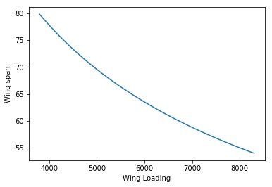

```python
##Plotting wing span vs. wing loading to get an idea about the numbers##

plt.plot(wing_loading,wing_span);
plt.xlabel("Wing Loading");
plt.ylabel("Wing span");
```

### Calculating required fuel volume

We assume that the density of aviation turbine fuel (ATF) is 0.804 kg/L at $15^{\circ}$C.

*(Source: https://en.wikipedia.org/wiki/Jet_fuel)*

This will give us another constraint on the maximum wing loading. (unless we decide to store fuel in additional fuel tanks, the fuselage or stability surfaces).

```python
##Caculation of volume of fuel required##

fuel_density = 0.804/l_to_mcube;
fuel_weight = fuel_weight_fraction*weight;
fuel_volume_required = fuel_weight/fuel_density;
print("Volume required on wing to store fuel : ",fuel_volume_required);
```

```
Volume required on wing to store fuel :  98.66857666312421
```

### Estimating volume available for fuel in wing

We use Torenbeek's method for estimating the fuel volume available. As stated in Roskam Part II page 153. Has an accuracy of 10%.

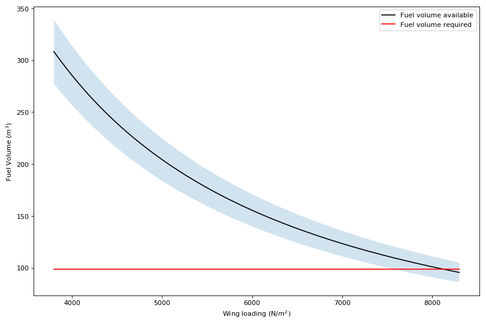

```python
##Estimation of wing fuel volume available##

fuel_volume_available = 0.54*((wing_area**2)/wing_span)*wing_t_by_c_root*(1+(wing_taper_ratio*(t_by_c_tip_by_root**0.5))+((wing_taper_ratio**2)*t_by_c_tip_by_root))/((1+wing_taper_ratio)**2);

plt.figure(figsize=(12, 8), dpi= 80, facecolor='w', edgecolor='k');
plt.plot(wing_loading,fuel_volume_available,color = 'black');
plt.plot(wing_loading,fuel_volume_required +(0*wing_loading),color = 'red');
plt.fill_between(wing_loading,0.9*fuel_volume_available,1.1*fuel_volume_available,alpha=0.2);
plt.legend({"Fuel volume available","Fuel volume required"});
plt.xlabel("Wing loading (N/$m^2$)");
plt.ylabel("Fuel Volume ($m^3$)");
```

### Estimating $C_{l_{max}}$ required to aid selection of airfoil (does NOT account twist)

We use the method provided in Roskam Part II page 168, but in a reverse way.

Wing $C_{L_{max}} = 1.05 \times C_{L_{max}}$ (Source: Roskam) (to include trim effects) (between 1.05 and 1.1)

```python
##Estimating required Cl_max##

wing_CL_max = 1.05*CL_max_clean;
unswept_wing_CL_max = wing_CL_max/np.cos(wing_qc_sweep);
Cl_max = unswept_wing_CL_max/0.95; ##0.95 factor for taper ratio less than 0.4. Assuming single airfoil throughout. If not, refer back to Roskam Part II page 168
print("Required $C_{l_{max}}$ is : ",Cl_max);
```

```
Required $C_{l_{max}}$ is :  1.9143719452077066
```

### Estimating design lift coefficient of airfoil at cruise using the same method above

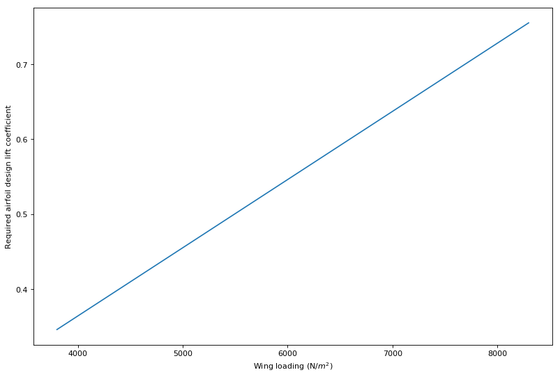

```python
##Estimating Cl_cruise

wing_CL_cruise = CL_cruise; ##as trim is minimal
unswept_wing_CL_cruise = wing_CL_cruise/np.cos(wing_qc_sweep);
Cl_cruise = unswept_wing_CL_cruise/0.95;
plt.figure(figsize=(12, 8), dpi= 80, facecolor='w', edgecolor='k');
plt.plot(wing_loading,Cl_cruise);
plt.xlabel("Wing loading (N/$m^2$)");
plt.ylabel("Required airfoil design lift coefficient");
```